# ISTANBUL Airbnb Price Prediction

Technical Report

Hasan Mansoor Khan

2023-02-12

## INTRODUCTION TO THE PROJECT

The prediction project aims to predict prices for certain Airbnb listings. These listings are specifically accommodations in Istanbul, Turkey that can accommodate 2 to 6 persons. Furthermore, the analysis, uses various constraints and/or filters to incorporate only certain types of properties. This allows for a more comprehensive data input to the various prediction models. With important data cleaning, the models run at efficiency and provide valuable insights.

- OLS linear regression
- LASSO
- Random Forest
- CART

However, before running the prediction models, this report aims to shed some light on the data cleaning and transformation of certain variables before running the machine learning predictive models.

## DATA SET OVERVIEW

The data used is based on a specific date which is 30th December 2022 & can be found on the official website : [Inside Airbnb](http://insideairbnb.com/get-the-data/). The specific data is an important aspect of the analysis as it constraints the time dimension of the analysis. The choice of *30th December 2022* is in mainly due to the fact that it is the most recently available data. When the raw data is imported, there are 36,717 observations for a total of 75 variables. This project must ideally include 10,000 plus observations. The 36,000 plus observations seem to be too high for the analysis. However, after various cleaning and transformations the observations reach close to the required 10,000 plus observations. It is important to note that each observation represents a single rental property listed at Airbnb. Meanwhile, the 75 variables show important characteristics including but not limited to price per day, property type, neighborhood, listing url and various amenities provided by the property.

## DATA WRANGLING

One of the most critical parts of this predictive analysis is data cleaning by removing errors, renaming columns, creating new variables, dropping irrelevant variables and creating a data set which is more accessible and efficient for the predictive models. In this regard I begin skimming the data set using Glimpse. I then proceed to limit by analysis by accommodates from 2 to 6 people. Furthermore, the most important variable for my analysis is the price per day which is the target variable. I mutate this variable into numeric type and remove the dollar signs.

Once the target variable is cleaned, I proceed to clean the predictor variables. These variables will be used to predict the value of the target variable.I drop columns that are not relevant for the analysis such as listing URL, scraping ID and many others. I then drop observations that have no value for target variable, price. Furthermore, I impute values for certain potential predictors including number of beds, accommodates and reviews. I then proceed to convert property types and neighborhood to factor variables & filter and keep only apartments and rental units as property types. Lastly, I use a function to extract the amenities and convert certain amenities as binary variables along with creating these amenities as dummy variables.

```r
# --------------------------- FILTER PROPERTY TYPES ------------------------ #
# property type is Entire serviced apartment, entire rental unit or Entire loft
data <- data %>%
  filter( property_type %in% c('Entire serviced apartment', 'Entire rental unit') )

# rename property_type categories
data <- data %>% mutate( property_type =
                         ifelse( property_type == 'Entire serviced apartment', 'apartment',
                         ifelse( property_type == 'Entire rental unit', 'rental',".")))

# property_type to factor variable
data <- data %>%
  mutate(f_property_type = factor(property_type))

# neighborhood_cleansed to factor variable
data <- data %>%
  mutate( f_neighbourhood = factor(neighbourhood_cleansed))
```

Once, the data is cleaned, I am have 16,187 observations and 32 variables. This data will be written as a clean version. The predictive models will have this clean data set as input data frame.

## EXPLORATORY DATA ANALYSIS

After completing data wrangling, my aim is to conduct exploratory data analysis. In other words, I want to know my data better. I have data for a single city Istanbul for a specific date, 30th December 2022. My goal is to understand the descriptive summary statistics of my data by visualizing its distribution. Apart from their distribution, I aim to identify the relationship between my predictor variables and target variable, price. The important distinction to make is between the target varaible: Price and the predictors: accommodates, amenities and property type. This can be refered to as:

- Label Engineering
- Feature Engineering

## LABEL ENGINEERING

Summary Statisitics of Price

| Variable | Mean | 5th Percentile | Median | 95th Percentile | Std | Min | Max | N |
| --- | --- | --- | --- | --- | --- | --- | --- | --- |
| price_day | 2535.07 | 599 | 1316 | 3909.2 | 27931.47 | 111 | 1793208 | 16187 |

As seen below, the target variable price has a relatively longer right tail. This is primarily due to the fact that the mean is larger than the median. Hence the price is slightly skewed. I conduct a log transformation & visualize its distribution which shows that it results in a slightly left side tail rather than normal distribution. Therefore, since log is not achieving a near perfect normal distribution, I decide to keep price as the main target variable rather than the transformation or log of price. Price seems normal to a great extent keeping in mind the inclusivity represented by price variable.

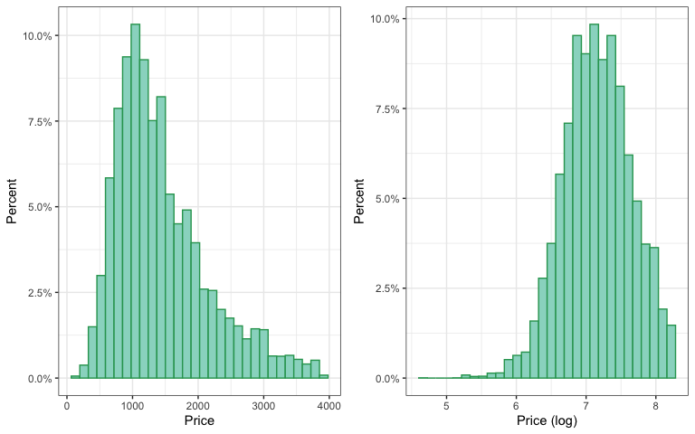

## FEATURE ENGINEERING

Feautre engineering is considered of the one of the most important considerations for a data analyst while conducting prediction models. Hence, great emphasis is placed on descriptive statistics, distributions and interactivity of predictor variables.

I then visualize the impact of accommodates and price. A clear trend can be identified, that as accommodation capacity increases, the price will increase also. However, to be more specific, a significant increase is visualized when a property has 4 accommodates instead of 3.

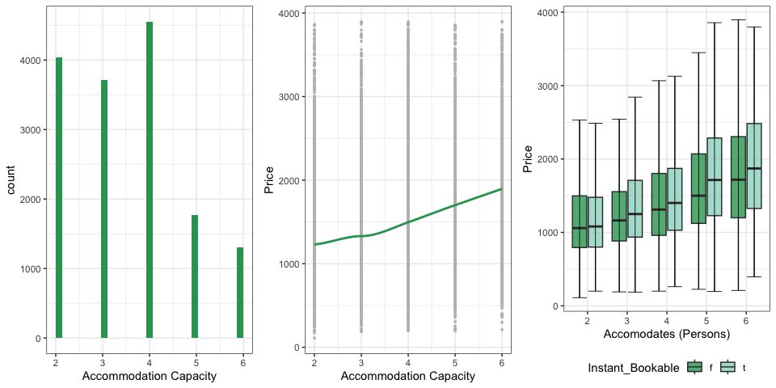

Another crucial predictor is the accommodation type and its distribution as well as impact on price. For this purpose, a box plot can be visualized showing the property type on the x axis with price on y axis while the box plots show the distribution across price. As seen below, apartments listings are relatively higher in price compared to rental units. This may be attributed to a multitude of factors for example apartments generally include those with higher accommodation capacity or great amenities which lead to a higher price distribution for apartments.

A box plot is also shown on the bottom right with accommodation capacity and type incorporated. This is box plots shows that for all accommodation capacities the apartments are higher in price compared to rental units. A minor exception is at accommodation capacity of 5 persons, where apartments or rentals are similarly priced.

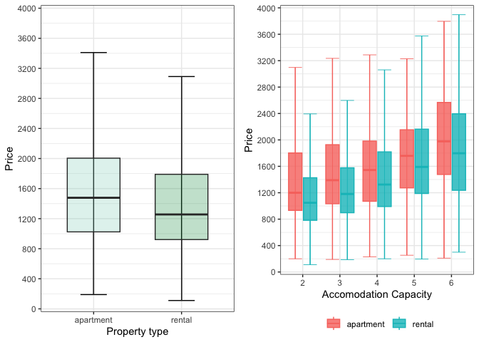

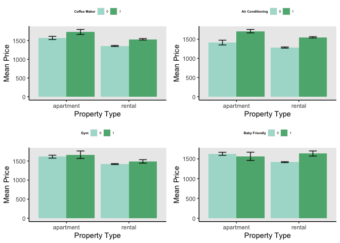

As part of Exploratory Data analysis, including label and feature engineering, I had the opportunity to know my data better and perform relevant data transformations.

## PREDICTION MODELS

The main goal of my analysis is Prediction of target variable price of a listing on Airbnb in Istanbul. To achieve this goal, I run 4 different prediction models as outlined in the introduction. These include, first of all, the Ordinary Least Squared or OLS model which contains specific models. I then proceed to run LASSO as my second model. My third prediction model is the Random Forest model which is significantly more complex compared to OLS and LASSO. Finally, to conclude, I run a Classification & Regression tree also known as CART. All prediction models, their underlying assumptions and key findings will be discussed separately for each model below. Finally, as a business analyst, I will conclude with my decision of predictive model with respect to efficiency, accuracy and relevance to business model of Airbnb.

As seen in the table below I create 3 prediction models in order to predict the target variable of price per day in Istanbul for Airbnb listings where the accommodates is from 2-6 persons. The cleaned version of data includes more than 15,000 observations which include two property types. The data is then split into a training set and a holdout set. 30% of the data at random was used as holdout set. I then used 5 fold cross validation Keeping in mind the number of observations of my data, a 5 fold cross validation will ensure accuracy of the predictions. With 5 folds, the data is split and 20% of the data will be tested in each fold. With multiple predictor variables incorporated, I calculate the RMSE on test and training set to determine which model would be the performing with highest accuracy.

**Versions of the Airbnb Apartment Price Prediction Models**

[output not shown]

## OLS

While deciphering the results of OLS, I have 3 key parameters to include: the RMSE, the R squared and BIC. My choice of OLS model will depend on striking the correct balance. Model 1 has an R-Squared value of 0.13, which means that 13% of the variance in the dependent variable is explained by the independent variables. It has a BIC value of 170406 and an RMSE value of 661.00. Model 2 has an R-Squared value of 0.19, which means that 19% of the variance in the dependent variable is explained by the independent variables. It has a BIC value of 169797 and an RMSE value of 640.19.Lastly, Model 3 has an R-Squared value of 0.19, which means that 19% of the variance in the dependent variable is explained by the independent variables. It has a BIC value of 169835 and an RMSE value of 639.81.

Based on these values, Model 2 appears to have the best balance between goodness of fit (R-Squared) and BIC. It has a higher R-Squared value than Model 1 and a lower BIC value than Model 3, indicating that it is more likely to be a good fit to the data while avoiding over fitting. Model 3 has a lower RMSE value than Models 1 and 2, but its BIC value is higher, indicating that it may be over fitting the data & hence not the ideal predictive model.

**Comparisng Model Fit measures**

| Model | N predictors | R-squared | BIC | Training RMSE | Test RMSE |
| --- | --- | --- | --- | --- | --- |
| Model 1 | 9 | 0.13 | 170406 | 661.00 | 660.25 |
| Model 2 | 20 | 0.19 | 169797 | 640.19 | 638.77 |
| Model 3 | 27 | 0.19 | 169835 | 639.81 | 638.00 |

## LASSO

Lasso is an important predictive modeling techniques as it aims to minimize the sum of squared residuals while shrinking the coefficients to zero. Running the LASSO returns me with a LASSO RMSE of 639.73, making the LASSO better in terms of RMSE. However, the simplicity of OLS model is a factor that cannot be over looked. The interpretation of OLS is simple as predictors are predefined and BIC scores also used to counter excessive use of predictors. Finally, the LASSO has a lower prediction error but a smaller R squared than OLS. The r squared is 0.185 making the OLS a better choice of predictive model compared to LASSO.

## RANDOM FOREST

The random forest adopts a method whereby it combines many decision trees to form a powerful predictive model. I begin by defining my 3 models for random forest: M1, M2 and M3. M1 considers numeric variables while M2 contains numeric as well as those in M1 which are numeric. Lastly, M3 considers all of the M1, M2 variables and adds amenities or dummy variables to the analysis. The predictors for M1, M2 and M3 are shown in the table below.

**Versions of the Airbnb Apartment Price Prediction Models for Random Forest**

| Model | Predictor Variables |
| --- | --- |
| M1 | = guests accommodated, number of beds, number of bedrooms, average review scores, |
| M2 | = M1 + f_property_type, f_minimum_nights,f_number_of_reviews, f_bathroom, |
| M3 | = M3 + all amenities columns |

Then a 5 factor cross validation is conducted while running the random forest predictive model. The average RMSE across all 5 folds are considered for Model 1, Model 2 and Model 3. The results show that model 3 has the lowest RMSE at 635.12. It suggests that it has the best fit to the data among the three models while Model 1 and 2 have relatively higher prediction error. Hence, for Random Forest, Model 3 has the best prediction with minimal RMSE.

**RMSE fold results for all models**

|  | Model 1 | Model 2 | Model 3 |
| --- | --- | --- | --- |
| Fold 1 | 670.0860 | 652.2040 | 632.1330 |
| Fold 2 | 659.8430 | 640.1630 | 624.1720 |
| Fold 3 | 668.0060 | 648.3640 | 626.8360 |
| Fold 4 | 679.8490 | 655.6830 | 637.5690 |
| Fold 5 | 687.3290 | 669.8600 | 654.9040 |
| Average | 673.0226 | 653.2548 | 635.1228 |

## PREDICTOR VARIABLES AND THEIR IMPORTANCE

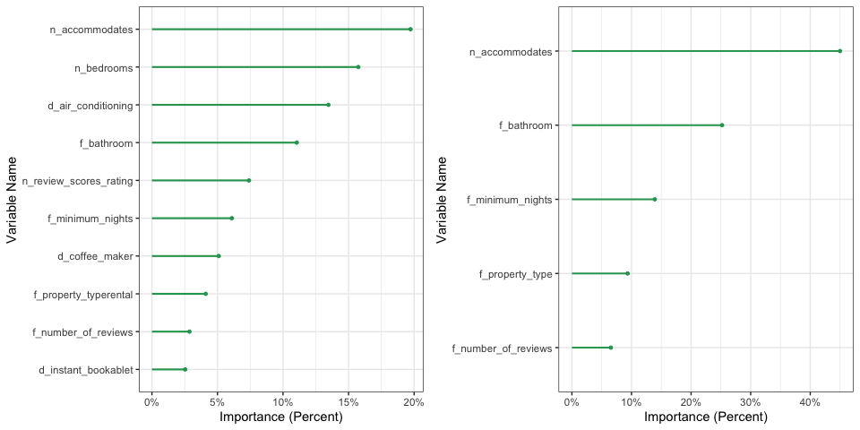

## PARTIAL DEPENDENCIES PLOT

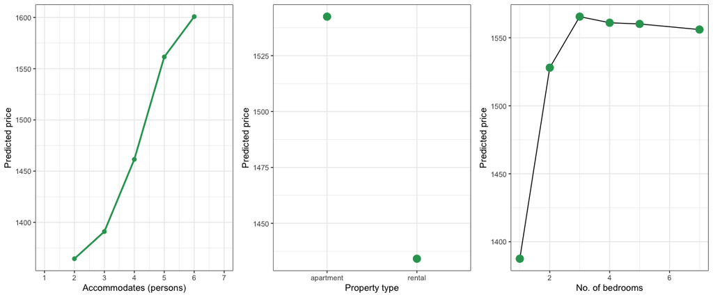

## CART

The last predictive model uses the Classification and Regression Tree also known as CART which builds a binary tree-like structure. Each node represents a binary decision. One of the key benefits of CART is interpretation as it can be visualized. However, the RMS for cart is very high compared to OLS and LASSO. The CART is producing a significantly higher RMSE and hence is not as accurate as other models. This may be due to the nature of the data or it is simply over fitting the data.

## Model Comparison

Model performance comparison

|  | CV RMSE | Holdout RMSE |
| --- | --- | --- |
| OLS Model 2 | 640.19 | 632.69 |
| LASSO (model with interactions) | 639.73 | 632.29 |
| CART | 666.18 | 663.30 |
| Random forest(with amenities) | 635.12 | 627.97 |

#### URL to github repository

[Github Repository](https://github.com/HasanMansoorKhan/Predictive-Models).

[Inside Airbnb](http://insideairbnb.com/get-the-data/).